# Books Project - Part 2

```python
import pandas as pd
import numpy as np
import matplotlib.pyplot as plt
import seaborn as sns
import plotly.express as px
import plotly.graph_objects as go
from plotly.subplots import make_subplots
```

```python
df = pd.read_csv('Amazonon_Bookreads_prepared_data.csv', sep='|', index_col=0)
```

```python
df_children_teens_books = pd.read_csv('Amazonon_Bookreads_children_teens_data.csv', sep='|', index_col=0)
```

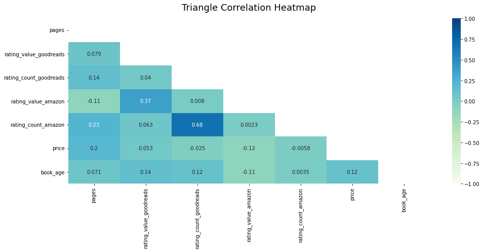

```python
#Choose columns which might correlate (numerical)
columns_relate = df[['pages', 'rating_value_goodreads', 'rating_count_goodreads', 'rating_value_amazon',\
                     'rating_count_amazon', 'price', 'book_age']]
plt.figure(figsize=(16, 6))

mask = np.triu(np.ones_like(columns_relate.corr(), dtype=bool))
heatmap = sns.heatmap(columns_relate.corr(), mask=mask, vmin=-1, vmax=1, annot=True, cmap='GnBu')
heatmap.set_title('Triangle Correlation Heatmap', fontdict={'fontsize':18}, pad=16);
```

### Reading group

- What reading group books cost more?
- What reading group books have more pages? Hypothesis is that adults books have more pages.

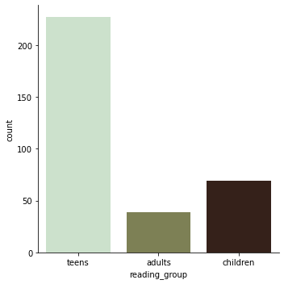

```python
#Count the books in each reading group
reading_group = df[df['reading_group'] != 'not stated']
sns.catplot(x='reading_group', kind='count', palette='ch:.90', data=reading_group)
```

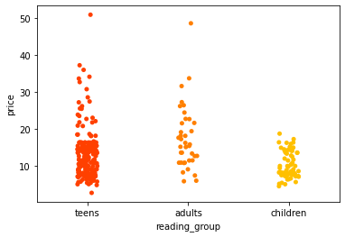

```python
#Prices of different reading groups books
sns.stripplot(x='reading_group', y='price', palette='autumn', data=reading_group)
```

```python
#Look at the outliers
reading_group.sort_values(by='price', ascending=False).head(2)
```

|  | title | author | description | pages | published_date | publisher | lexile_measure | grade_level | weight | rating_value_goodreads | ... | genre_4_weight | genre_5_weight | genre_6_weight | genre_7_weight | genre_8_weight | genre_9_weight | price | book_age | reading_group | bookedition_new |
| --- | --- | --- | --- | --- | --- | --- | --- | --- | --- | --- | --- | --- | --- | --- | --- | --- | --- | --- | --- | --- | --- |
| 18 | Daughter of Smoke & Bone | Laini Taylor | Around the world, black hand prints are appear... | 418.0 | 2011-09-27 | Little, Brown and Company | 850L | 10 and up | 657.70840 | 3.99 | ... | 0.053337 | 0.050236 | 0.041297 | 0.032116 | 0.026548 | 0.019926 | 50.92 | 11.0 | teens | 0 |
| 498 | Tower Lord | Anthony Ryan | “The blood-song rose with an unexpected tune, ... | 602.0 | 2014-07-01 | Ace | NaN | NaN | 852.75296 | 4.17 | ... | 0.020952 | 0.019429 | 0.015238 | 0.014095 | 0.012952 | 0.011048 | 48.60 | 8.0 | adults | 0 |

2 rows × 37 columns

```python
#Set nan price for these books
df.at[18, 'price'] = np.nan
df.at[498, 'price'] = np.nan
```

```python
#Number of pages of different reading groups books
fig = px.box(reading_group, x='reading_group', y='pages', points='all', title='Number of pages of different reading groups books')
fig.show()
```

[interactive chart not shown]

### Lexile_code

using df_children_teens_books

- Hypothesis is most books have High-Low code (easy to read but higly intresting)
- Hypothesis is High-Low code books have higher rating

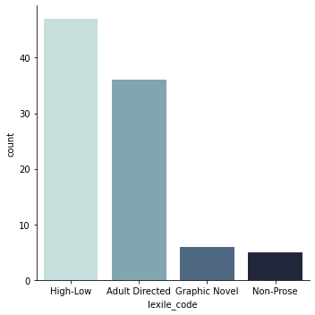

```python
#Check the number of different lexile code books.
sns.catplot(x='lexile_code', kind='count', palette='ch:rot=-.25', data=df_children_teens_books)
```

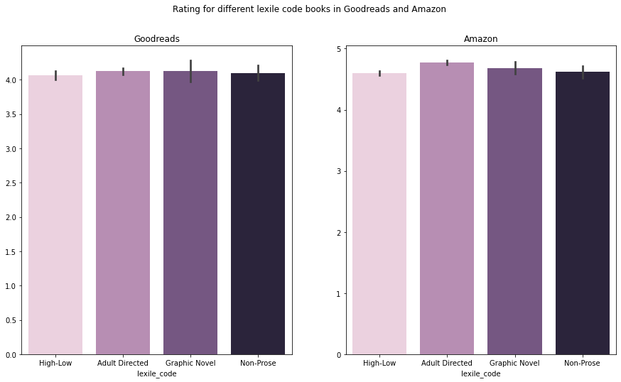

```python
#Check High-Low code books raiting in Goodreads and Amazon
fig, axes = plt.subplots(1, 2, sharex=True, figsize=(15,8))

fig.suptitle('Rating for different lexile code books in Goodreads and Amazon')

axes[0].set_title('Goodreads')
axes[1].set_title('Amazon')
palette='ch:rot=.25'

sns.barplot(ax=axes[0], x=df_children_teens_books.lexile_code, y=df_children_teens_books.rating_value_goodreads.values, palette=palette)
sns.barplot(ax=axes[1], x=df_children_teens_books.lexile_code, y=df_children_teens_books.rating_value_amazon.values, palette=palette)
```

Conclusions:

### Book age

- What is books distribution age-wise among different reading groups?
- Do older books have higher rating?

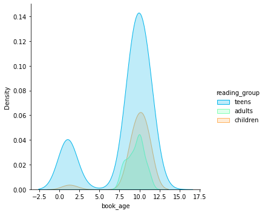

```python
#Check the distribution of book_age
sns.displot(reading_group, x='book_age', hue='reading_group', kind='kde', palette='rainbow', fill=True)
```

```python
fig = go.Figure()
fig.add_trace(go.Scatter(x=df.book_age, y=df.rating_value_goodreads,
                    mode='markers',
                    name='Goodreads rating'))
fig.add_trace(go.Scatter(x=df.book_age, y=df.rating_value_amazon,
                    mode='markers',
                    name='Amazon rating'))
fig.update_layout(title='Rating in Goodreads and Amazon for different age books',
                   xaxis_title='book age',
                   yaxis_title='rating')
fig.show()
```

[interactive chart not shown]

Conclusions:

- Most books were published 10 years ago. But there are new books for teens and children.
- Old books and new books have the same rating.

### Genre

- What are the most popular genres?
- What genres are most expensive?

```python
main_genre = df.main_genre.dropna()
fig = px.pie(df, names=main_genre, color_discrete_sequence=px.colors.sequential.Sunset)
fig.update_traces(textposition='inside')
fig.update_layout(uniformtext_minsize=12, uniformtext_mode='hide', title='Genre composition')
fig.show()
```

[interactive chart not shown]

```python
max_prices = df[['main_genre', 'price']].dropna().groupby(['main_genre']).max().reset_index()
mean_prices = df[['main_genre', 'price']].dropna().groupby(['main_genre']).mean().reset_index()

fig = go.Figure(data=[
    go.Bar(name='max price', x=max_prices.main_genre, y=max_prices.price),
    go.Bar(name='mean price', x=mean_prices.main_genre, y=mean_prices.price)
])
# Change the bar mode
fig.update_layout(barmode='overlay', title='Max and mean price for each genre')
fig.show()
```

[interactive chart not shown]

```python
goodreads_rating = df[['main_genre', 'rating_value_goodreads']].dropna().groupby(['main_genre']).mean().reset_index()
fig = px.scatter(goodreads_rating, y='rating_value_goodreads', x='main_genre', color='main_genre',
                 title='Rating of each genre according to Goodreads users', text='main_genre')
fig.update_traces(marker_size=15)
fig.show()
```

[interactive chart not shown]

Preliminary conclusion:

Spirituality and Mystery Thriller are the most higly rated in Goodreads. Cristian books have the smallest raiting.

However, some genres have only one occurrence in the data set. The second experoment will include only genres which have more than 20 occurrences.

```python
#Choose genres which occurr in the data set more than 20 times
most_genres1 = df[['main_genre', 'rating_value_goodreads']].dropna().groupby(['main_genre']).count()\
.sort_values(by='rating_value_goodreads', ascending=True).reset_index()
most_genres2 = most_genres1[most_genres1['rating_value_goodreads'] > 20]
```

```python
#Create a list of these genres
genres_list = most_genres2['main_genre'].to_list()
```

```python
#Create a new dataframe which contains only 20+ occurrences of genres
goodreads_rating_top = goodreads_rating[goodreads_rating['main_genre'].isin(genres_list)]
```

```python
fig = px.scatter(goodreads_rating_top, y='rating_value_goodreads', x='main_genre', color='main_genre',
                 title='Rating of most popular genres according to Goodreads users', text='main_genre')
fig.update_traces(marker_size=15)
fig.show()
```

[interactive chart not shown]

Conclusion:

Paranormal books have the biggest raiting while Horror books have the smallest. It is intresting that Nonefiction (the most popular genre) has average rating 4.

### Number of pages

- Do longer books cost more?

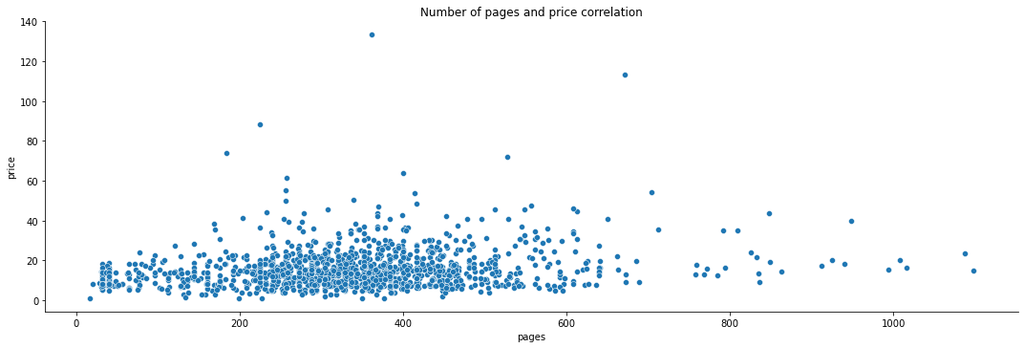

```python
#Find relations between number of pages and price
sns.relplot(x='pages', y='price', kind='scatter', aspect=3, data=df).set(title='Number of pages and price correlation')
```

### First edition

- Do first edition books cost more?

```
[Text(0.5, 1.0, 'Book edition and price correlation')]
```

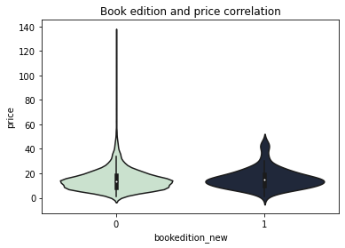

```python
sns.violinplot(x='bookedition_new', y='price', data=df, palette='ch:rot=-.40', gridsize=80)\
.set(title='Book edition and price correlation')
```

Conclusion:

Hypothesis 'First editiom books cost more' - disproved